# Replication Output for: Can the Government Deter Discrimination? Evidence from a Randomized Intervention in New York City

Albert H. Fang, Andrew M. Guess, and Macartan Humphreys

October 3, 2018

- [This .Rmd file](https://github.com/medinali/F-G-H_2018/blob/master/Replicate_Main.Rmd) produces the tables, figures, and analyses reported in the manuscript and in the [(online) appendix](https://www.journals.uchicago.edu/doi/suppl/10.1086/700107) from [“*Can the Government Deter Discrimination? Evidence from a Randomized Intervention in New York City*”](http://www.macartan.nyc/wp-content/uploads/2018/11/FGH_Paper.pdf). This output file shows the core code and analyses used, as well as the main output from these analyses.
- We begin with a walk-through, through one set of results, step by step. We then introduce the automated analysis that replicates the core tables and figures reported in the paper.
- Analyses reported in the online appendix are produced optionally (the default setting is to produce these results).
- At various points in this Rmd file, we have set `echo=F` and `eval=F` in selected R code chunks to suppress displaying tex output in the Rmd output. To have these code chunks produce .tex table output files, set `eval=T`.
- If you want to load [data](https://dataverse.harvard.edu/dataset.xhtml?persistentId=doi:10.7910/DVN/CF44OW) from Dataverse, in the second code chunk you must (1) set `local_data=FALSE` and (2) set your Dataverse API token in the line `Sys.setenv("DATAVERSE_KEY" = "ENTER-YOUR-API-TOKEN-HERE")`.
- [Replication code files](https://github.com/medinali/F-G-H_2018) can be found online.

# 1 Housekeeping

```r
  # Set seed
  set.seed(20150229)

  # Load data locally or from dataverse
  # -- if TRUE: Data must be saved in the local root directory (specified in above code chunk)
  # -- if FALSE: Data will load from Dataverse; you must have a Dataverse API Token
  local_data <- TRUE
  if(!local_data){
    Sys.setenv("DATAVERSE_KEY" = "ENTER-YOUR-API-TOKEN-HERE")  ##### Put your Dataverse API Token here.
    Sys.setenv("DATAVERSE_SERVER" = "dataverse.harvard.edu")
  }
  source("code_0_read_data.R")

  # Load helper functions and prepare data
  source("code_1a_prep_data.R")
  source("code_1b_helper_functions.R")
```

# 2 Manual walkthrough

We start by showing how to do a simple manual replication of core results. The remainder of this code does this same thing in a more automated way across various combinations.

## 2.1 Treatment Levels

There are three treatment levels:

```r
table(dat$TA)
```

```
  0   1   2
279 174 200
```

These correspond to

0. control (c)
1. monitoring (m) and
2. punitive (p).

The key comparisons are thus:

- mc (1 v 0)
- pc (2 v 0)
- pm (2 v 1)

For simplicity the code uses TA1 as a dummy for m, and TA2 as a dummy for p

## 2.2 Racial groups

There are also three groups: Blacks (b), Hispanics (h), Whites (w). These yield three intergroup comparisons:

- wb (white - Black)
- wh (white - Hispanic)
- bh (Black - Hispanic)

## 2.3 Outcomes

There are four outcomes that have been defined as between group differences (i.e., net discrimination measures). The stubs for these are:

```r
outvars <- c("nmeet_", "index.", "ncb_", "noff_")
```

Let’s examine one set of outcome variables, the “ncb” (net discrimination in callbacks) variables:

```r
head(dplyr::select(dat, starts_with("ncb")))
```

```
  ncb_bh ncb_wb ncb_wh
1      0     -1     -1
2      0      0      0
3      0      0      0
4      0      0      0
5      0      1      1
6      1     -1      0
```

```r
table(dat$ncb_wh)
```

```
 -1   0   1
 55 520  78
```

## 2.4 Parametric Analysis

The punitive-control comparison is done:

```r
manual_model <- lm(ncb_wh ~ TA2 + as.factor(block), data=filter(dat, TA %in% c(0,2)), weights = ipw20)
stargazer(manual_model,  omit = "block", type = "html")
```

|  | *Dependent variable:* |
| --- | --- |
|  | ncb_wh |
| TA2 | -0.066 |
|  | (0.041) |
| Constant | 0.068 |
|  | (0.083) |
| Observations | 479 |
| R<sup>2</sup> | 0.032 |
| Adjusted R<sup>2</sup> | -0.004 |
| Residual Std. Error | 0.633 (df = 461) |
| F Statistic | 0.888 (df = 17; 461) |
| *Note:* | p<0.1; p<0.05; p<0.01 |

This might be compared with:

1. The “non-parametric” analysis which uses blocked differences in means

```r
difference_in_means(ncb_wh ~ TA2, blocks = block, data=filter(dat, (block !=5) & (TA %in% c(0,2))))
```

```
Design:  Blocked
       Estimate Std. Error   t value  Pr(>|t|)   CI Lower  CI Upper  DF
TA2 -0.06417621 0.04483847 -1.431276 0.1530515 -0.1522971 0.0239447 446
```

Note that we exclude the block 5 for lack of units to calculate withn block variance:

```r
table(dat$TA2, dat$block)
```

```
     1  2  3  4  5  6  7  8  9 10 11 12 13 14 15 16 17
  0 25  7 25  5  2 16 87 31 82 38 10 15 36  9 43 15  7
  1 17  2 18  6  0  9 29 11 23 14  3  4 14  8 25 14  3
```

2. A version of lm that uses robust standard errors

```r
lm_robust(ncb_wh ~ TA2, fixed_effects =  ~ block, data=filter(dat, TA %in% c(0,2)), weights = ipw20)
```

```
       Estimate Std. Error   t value  Pr(>|t|)  CI Lower   CI Upper  DF
TA2 -0.06603413 0.04450348 -1.483797 0.1385462 -0.153489 0.02142069 461
```

3. A raw cross tab (no weights)

```r
with(data=filter(dat, (block !=5) & (TA %in% c(0,2))), table(ncb_wh, TA2))
```

```
      TA2
ncb_wh   0   1
    -1  18  20
    0  225 159
    1   35  21
```

Note that the main differences between the parametric and non parametric approach is that the non parametric approach allows between block heterogeneity in average effects; in addition rather than using the assignment propensities it implictly uses information on the empirical shares in each condition in each block.

Note when examining different models that the following generally need to be adjusted:

- The outcome
- The treatment (TA2 here since we are interested in punitive)
- The data (to condition on the right comparisons, here `TA %in% c(0,2)`)
- The weights (here ipw20, since we are interested in comparing TA=2 and TA=0)

The core replication code automates these multiple adjustments, but any individual analysis can be checked manually, as above.

## 2.5 Posteriors

Posterior simulation using approach from Gelman and Hill (`arm` package):

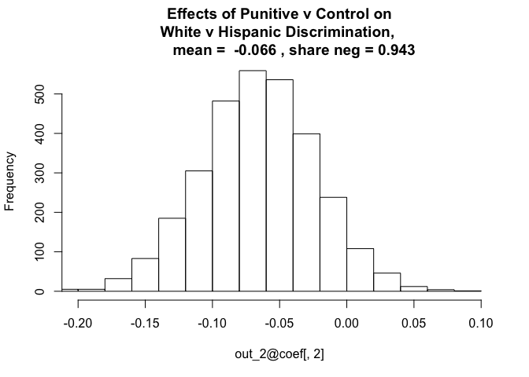

```r
out_2 <- sim(manual_model, 3000)

hist(out_2@coef[,2], main = paste(
      "Effects of Punitive v Control on\nWhite v Hispanic Discrimination,
       mean = ", round(mean(out_2@coef[,2]), 3),
      ", share neg =", round(mean(out_2@coef[,2] < 0), 3)
      ),
     xlim = c(-.2, .1))
```

# 3 Tables and Figures in Main Text

## 3.1 Parametric Results on Discrimination Levels and Treatment Effects:

### 3.1.1 Code for Analyses

```r
# ---------------------------------------------------------------------- #
# DEFINE COLNAMES FOR OUTPUT TABLES

col.labels <- c("Outcome", "Estimate","SE","t","P")
# mc: monitoring - control
# pc: punitive - control
# pm: punitive - monitoring
# TA1: monitoring
# TA2: punitive

outvars <- c("nmeet_", "index.", "ncb_", "noff_")

reg_and_summ <- function(outvar, compare){

  depvar <- paste0(outvar, compare)
  model.mc <- paste(depvar," ~ TA1 + as.factor(block)",sep="")
  model.pc <- paste(depvar," ~ TA2 + as.factor(block)",sep="")
  model.pm <- paste(depvar," ~ TA2 + as.factor(block)",sep="")


  fit.mc <- lm(formula=model.mc, data=dat[dat$TA %in% c(0,1),], weights = ipw10)
  fit.pc <- lm(formula=model.pc, data=dat[dat$TA %in% c(0,2),], weights = ipw20)
  fit.pm <- lm(formula=model.pm, data=dat[dat$TA %in% c(1,2),], weights = ipw21)


  itt.mc <- summary(fit.mc)$coefficients[2,]
  itt.pc <- summary(fit.pc)$coefficients[2,]
  itt.pm <- summary(fit.pm)$coefficients[2,]

  if(compare == "wb" | compare == "wh"  ){
  itt.mc[4] <- pt(coef(summary(fit.mc))[,3], summary(fit.mc)$df[2], lower=TRUE)[2] #one sided p
  itt.pc[4] <- pt(coef(summary(fit.pc))[,3], summary(fit.pc)$df[2], lower=TRUE)[2] #one sided p
  }

    list(mc     = itt.mc, pc     = itt.pc, pm     = itt.pm,
         fit.mc = fit.mc, fit.pc = fit.pc, fit.pm = fit.pm )

}

# Parametric Differences in Differences Results - White / Black Comparisons
itt.wb <- lapply(outvars, reg_and_summ,  compare = "wb" )
fit.wb.mc <- sapply(1:length(outvars), function(i) itt.wb[[i]]$fit.mc)
fit.wb.pc <- sapply(1:length(outvars), function(i) itt.wb[[i]]$fit.pc)
fit.wb.pm <- sapply(1:length(outvars), function(i) itt.wb[[i]]$fit.pm)

# Parametric Differences in Differences Results - White / Hispanic Comparisons
itt.wh <- lapply(outvars, reg_and_summ,  compare = "wh" )
fit.wh.mc <- sapply(1:length(outvars), function(i) itt.wh[[i]]$fit.mc)
fit.wh.pc <- sapply(1:length(outvars), function(i) itt.wh[[i]]$fit.pc)
fit.wh.pm <- sapply(1:length(outvars), function(i) itt.wh[[i]]$fit.pm)

# Parametric Differences in Differences Results - Black / Hispanic Comparisons
itt.bh <- lapply(outvars, reg_and_summ,  compare = "bh" )
fit.bh.mc <- sapply(1:length(outvars), function(i) itt.bh[[i]]$fit.mc)
fit.bh.pc <- sapply(1:length(outvars), function(i) itt.bh[[i]]$fit.pc)
fit.bh.pm <- sapply(1:length(outvars), function(i) itt.bh[[i]]$fit.pm)
```

### 3.1.2 Simple print out of parametric results

```r
# WB MC
stargazer(fit.wb.mc[[1]], fit.wb.mc[[2]], fit.wb.mc[[3]], fit.wb.mc[[4]],
          omit = "block", type = "html",
          p = lapply(fit.wb.mc, function(fit)
            pt(coef(summary(fit))[,3], summary(fit)$df[2], lower=TRUE) ))
```

|  | *Dependent variable:* |  |  |  |
| --- | --- | --- | --- | --- |
|  | nmeet_wb | index.wb | ncb_wb | noff_wb |
|  | (1) | (2) | (3) | (4) |
| TA1 | 0.051 | -0.015 | -0.002 | -0.003 |
|  | (0.038) | (0.052) | (0.045) | (0.036) |
| Constant | -0.103 | 0.020 | 0.121 | -0.039 |
|  | (0.081) | (0.104) | (0.097) | (0.078) |
| Observations | 453 | 331 | 453 | 453 |
| R<sup>2</sup> | 0.065 | 0.058 | 0.035 | 0.041 |
| Adjusted R<sup>2</sup> | 0.029 | 0.007 | -0.003 | 0.004 |
| Residual Std. Error | 0.560 (df = 435) | 0.641 (df = 313) | 0.673 (df = 435) | 0.538 (df = 435) |
| F Statistic | 1.791** (df = 17; 435) | 1.129 (df = 17; 313) | 0.929 (df = 17; 435) | 1.099 (df = 17; 435) |
| *Note:* | p<0.1; p<0.05; p<0.01 |  |  |  |

```r
# WB PC
stargazer(fit.wb.pc[[1]], fit.wb.pc[[2]], fit.wb.pc[[3]], fit.wb.pc[[4]],
          omit = "block", type = "html" )
```

|  | *Dependent variable:* |  |  |  |
| --- | --- | --- | --- | --- |
|  | nmeet_wb | index.wb | ncb_wb | noff_wb |
|  | (1) | (2) | (3) | (4) |
| TA2 | 0.039 | 0.007 | 0.019 | 0.018 |
|  | (0.038) | (0.053) | (0.042) | (0.035) |
| Constant | -0.054 | 0.043 | 0.054 | -0.010 |
|  | (0.077) | (0.103) | (0.086) | (0.071) |
| Observations | 479 | 354 | 479 | 479 |
| R<sup>2</sup> | 0.042 | 0.012 | 0.043 | 0.055 |
| Adjusted R<sup>2</sup> | 0.007 | -0.038 | 0.007 | 0.020 |
| Residual Std. Error | 0.585 (df = 461) | 0.686 (df = 336) | 0.649 (df = 461) | 0.535 (df = 461) |
| F Statistic | 1.196 (df = 17; 461) | 0.234 (df = 17; 336) | 1.209 (df = 17; 461) | 1.578* (df = 17; 461) |
| *Note:* | p<0.1; p<0.05; p<0.01 |  |  |  |

```r
# WB PM
stargazer(fit.wb.pm[[1]], fit.wb.pm[[2]], fit.wb.pm[[3]], fit.wb.pm[[4]],
          omit = "block", type = "html",
          p = lapply(fit.wb.pm, function(fit)
            pt(coef(summary(fit))[,3], summary(fit)$df[2], lower=TRUE) ))
```

|  | *Dependent variable:* |  |  |  |
| --- | --- | --- | --- | --- |
|  | nmeet_wb | index.wb | ncb_wb | noff_wb |
|  | (1) | (2) | (3) | (4) |
| TA2 | -0.005 | 0.018 | 0.033 | 0.026 |
|  | (0.045) | (0.058) | (0.049) | (0.037) |
| Constant | 0.039 | 0.189 | 0.087 | 0.020 |
|  | (0.085) | (0.102) | (0.093) | (0.070) |
| Observations | 374 | 263 | 374 | 374 |
| R<sup>2</sup> | 0.062 | 0.052 | 0.015 | 0.054 |
| Adjusted R<sup>2</sup> | 0.017 | -0.009 | -0.032 | 0.009 |
| Residual Std. Error | 0.605 (df = 356) | 0.638 (df = 246) | 0.656 (df = 356) | 0.499 (df = 356) |
| F Statistic | 1.385 (df = 17; 356) | 0.850 (df = 16; 246) | 0.324 (df = 17; 356) | 1.205 (df = 17; 356) |
| *Note:* | p<0.1; p<0.05; p<0.01 |  |  |  |

```r
# WH MC
stargazer(fit.wh.mc[[1]], fit.wh.mc[[2]], fit.wh.mc[[3]], fit.wh.mc[[4]],
          omit = "block", type = "html",
          p = lapply(fit.wh.mc, function(fit)
            pt(coef(summary(fit))[,3], summary(fit)$df[2], lower=TRUE) ) )
```

|  | *Dependent variable:* |  |  |  |
| --- | --- | --- | --- | --- |
|  | nmeet_wh | index.wh | ncb_wh | noff_wh |
|  | (1) | (2) | (3) | (4) |
| TA1 | -0.024 | -0.061 | -0.036 | -0.017 |
|  | (0.041) | (0.057) | (0.043) | (0.034) |
| Constant | -0.110 | 0.072 | 0.176 | 0.047 |
|  | (0.087) | (0.113) | (0.093) | (0.073) |
| Observations | 453 | 318 | 453 | 453 |
| R<sup>2</sup> | 0.093 | 0.031 | 0.039 | 0.054 |
| Adjusted R<sup>2</sup> | 0.058 | -0.024 | 0.001 | 0.017 |
| Residual Std. Error | 0.600 (df = 435) | 0.693 (df = 300) | 0.641 (df = 435) | 0.506 (df = 435) |
| F Statistic | 2.638*** (df = 17; 435) | 0.571 (df = 17; 300) | 1.040 (df = 17; 435) | 1.464 (df = 17; 435) |
| *Note:* | p<0.1; p<0.05; p<0.01 |  |  |  |

```r
# WH PC
stargazer(fit.wh.pc[[1]], fit.wh.pc[[2]], fit.wh.pc[[3]], fit.wh.pc[[4]],
          omit = "block", type = "html",
          p = lapply(fit.wh.pc, function(fit)
            pt(coef(summary(fit))[,3], summary(fit)$df[2], lower=TRUE) ))
```

|  | *Dependent variable:* |  |  |  |
| --- | --- | --- | --- | --- |
|  | nmeet_wh | index.wh | ncb_wh | noff_wh |
|  | (1) | (2) | (3) | (4) |
| TA2 | -0.003 | 0.048 | -0.066* | -0.021 |
|  | (0.039) | (0.055) | (0.041) | (0.034) |
| Constant | 0.002 | 0.085 | 0.068 | 0.012 |
|  | (0.078) | (0.107) | (0.083) | (0.069) |
| Observations | 479 | 346 | 479 | 479 |
| R<sup>2</sup> | 0.048 | 0.068 | 0.032 | 0.059 |
| Adjusted R<sup>2</sup> | 0.013 | 0.020 | -0.004 | 0.024 |
| Residual Std. Error | 0.594 (df = 461) | 0.714 (df = 328) | 0.633 (df = 461) | 0.524 (df = 461) |
| F Statistic | 1.367 (df = 17; 461) | 1.405 (df = 17; 328) | 0.888 (df = 17; 461) | 1.702** (df = 17; 461) |
| *Note:* | p<0.1; p<0.05; p<0.01 |  |  |  |

```r
# WH PM
stargazer(fit.wh.pm[[1]], fit.wh.pm[[2]], fit.wh.pm[[3]], fit.wh.pm[[4]],
          omit = "block", type = "html")
```

|  | *Dependent variable:* |  |  |  |
| --- | --- | --- | --- | --- |
|  | nmeet_wh | index.wh | ncb_wh | noff_wh |
|  | (1) | (2) | (3) | (4) |
| TA2 | 0.017 | 0.107* | -0.019 | 0.002 |
|  | (0.045) | (0.063) | (0.049) | (0.038) |
| Constant | 0.025 | 0.127 | -0.024 | -0.037 |
|  | (0.084) | (0.112) | (0.093) | (0.072) |
| Observations | 374 | 268 | 374 | 374 |
| R<sup>2</sup> | 0.047 | 0.089 | 0.027 | 0.049 |
| Adjusted R<sup>2</sup> | 0.001 | 0.031 | -0.020 | 0.004 |
| Residual Std. Error | 0.598 (df = 356) | 0.703 (df = 251) | 0.661 (df = 356) | 0.511 (df = 356) |
| F Statistic | 1.029 (df = 17; 356) | 1.539* (df = 16; 251) | 0.578 (df = 17; 356) | 1.077 (df = 17; 356) |
| *Note:* | p<0.1; p<0.05; p<0.01 |  |  |  |

```r
# BH MC
stargazer(fit.bh.mc[[1]], fit.bh.mc[[2]], fit.bh.mc[[3]], fit.bh.mc[[4]],
          omit = "block", type = "html")
```

|  | *Dependent variable:* |  |  |  |
| --- | --- | --- | --- | --- |
|  | nmeet_bh | index.bh | ncb_bh | noff_bh |
|  | (1) | (2) | (3) | (4) |
| TA1 | -0.075* | -0.089* | -0.035 | -0.014 |
|  | (0.042) | (0.052) | (0.042) | (0.031) |
| Constant | -0.007 | 0.057 | 0.055 | 0.086 |
|  | (0.089) | (0.098) | (0.090) | (0.066) |
| Observations | 453 | 316 | 453 | 453 |
| R<sup>2</sup> | 0.088 | 0.058 | 0.037 | 0.012 |
| Adjusted R<sup>2</sup> | 0.053 | 0.004 | -0.0002 | -0.027 |
| Residual Std. Error | 0.614 (df = 435) | 0.636 (df = 298) | 0.624 (df = 435) | 0.455 (df = 435) |
| F Statistic | 2.477*** (df = 17; 435) | 1.075 (df = 17; 298) | 0.995 (df = 17; 435) | 0.309 (df = 17; 435) |
| *Note:* | p<0.1; p<0.05; p<0.01 |  |  |  |

```r
# BH PC
stargazer(fit.bh.pc[[1]], fit.bh.pc[[2]], fit.bh.pc[[3]], fit.bh.pc[[4]],
          omit = "block", type = "html")
```

|  | *Dependent variable:* |  |  |  |
| --- | --- | --- | --- | --- |
|  | nmeet_bh | index.bh | ncb_bh | noff_bh |
|  | (1) | (2) | (3) | (4) |
| TA2 | -0.042 | 0.039 | -0.085** | -0.039 |
|  | (0.041) | (0.049) | (0.041) | (0.033) |
| Constant | 0.056 | 0.052 | 0.015 | 0.021 |
|  | (0.082) | (0.090) | (0.082) | (0.068) |
| Observations | 479 | 340 | 479 | 479 |
| R<sup>2</sup> | 0.051 | 0.069 | 0.039 | 0.023 |
| Adjusted R<sup>2</sup> | 0.016 | 0.020 | 0.004 | -0.013 |
| Residual Std. Error | 0.624 (df = 461) | 0.625 (df = 322) | 0.623 (df = 461) | 0.512 (df = 461) |
| F Statistic | 1.452 (df = 17; 461) | 1.400 (df = 17; 322) | 1.109 (df = 17; 461) | 0.634 (df = 17; 461) |
| *Note:* | p<0.1; p<0.05; p<0.01 |  |  |  |

```r
# BH PM
stargazer(fit.bh.pm[[1]], fit.bh.pm[[2]], fit.bh.pm[[3]], fit.bh.pm[[4]],
          omit = "block", type = "html")
```

|  | *Dependent variable:* |  |  |  |
| --- | --- | --- | --- | --- |
|  | nmeet_bh | index.bh | ncb_bh | noff_bh |
|  | (1) | (2) | (3) | (4) |
| TA2 | 0.023 | 0.139** | -0.052 | -0.024 |
|  | (0.051) | (0.057) | (0.047) | (0.036) |
| Constant | -0.014 | -0.077 | -0.111 | -0.057 |
|  | (0.096) | (0.100) | (0.088) | (0.067) |
| Observations | 374 | 250 | 374 | 374 |
| R<sup>2</sup> | 0.067 | 0.118 | 0.036 | 0.036 |
| Adjusted R<sup>2</sup> | 0.023 | 0.057 | -0.010 | -0.010 |
| Residual Std. Error | 0.683 (df = 356) | 0.622 (df = 233) | 0.626 (df = 356) | 0.477 (df = 356) |
| F Statistic | 1.511* (df = 17; 356) | 1.943** (df = 16; 233) | 0.793 (df = 17; 356) | 0.785 (df = 17; 356) |
| *Note:* | p<0.1; p<0.05; p<0.01 |  |  |  |

### 3.1.3 Storing parametric results

```r
# Parametric Differences in Differences Results -White / Black Comparisons
itt.wb.mc <- sapply(1:length(outvars), function(i) itt.wb[[i]]$mc)
itt.wb.pc <- sapply(1:length(outvars), function(i) itt.wb[[i]]$pc)
itt.wb.pm <- sapply(1:length(outvars), function(i) itt.wb[[i]]$pm)

# Parametric Differences in Differences Results - White / Hispanic Comparisons
itt.wh.mc <- sapply(1:length(outvars), function(i) itt.wh[[i]]$mc)
itt.wh.pc <- sapply(1:length(outvars), function(i) itt.wh[[i]]$pc)
itt.wh.pm <- sapply(1:length(outvars), function(i) itt.wh[[i]]$pm)

# Parametric Differences in Differences Results - Black / Hispanic Comparisons
itt.bh.mc <- sapply(1:length(outvars), function(i) itt.bh[[i]]$mc)
itt.bh.pc <- sapply(1:length(outvars), function(i) itt.bh[[i]]$pc)
itt.bh.pm <- sapply(1:length(outvars), function(i) itt.bh[[i]]$pm)


#----- CIs -----#
df.w_ <- sapply(list(df.wb.mc = fit.wb.mc,
                     df.wb.pc = fit.wb.pc,
                     df.wb.pm = fit.wb.pm,
                     df.wh.mc = fit.wh.mc,
                     df.wh.pc = fit.wh.pc,
                     df.wh.pm = fit.wh.pm,
                     df.bh.mc = fit.bh.mc,
                     df.bh.pc = fit.bh.pc,
                     df.bh.pm = fit.bh.pm),
                function(fit){
                        unlist(lapply(fit, function(x) summary(x)$df[2]))[2:4]})

df.2g.10 <-  c(df.w_[,c("df.wb.mc", "df.wh.mc", "df.bh.mc")])
df.2g.20 <-  c(df.w_[,c("df.wb.pc", "df.wh.pc", "df.bh.pc")])
df.2g.21 <-  c(df.w_[,c("df.wb.pm", "df.wh.pm", "df.bh.pm")])

cv.2g.10 <- qt(p=0.025, df=df.2g.10, lower.tail=TRUE)
cv.2g.20 <- qt(p=0.025, df=df.2g.20, lower.tail=TRUE)
cv.2g.21 <- qt(p=0.025, df=df.2g.21, lower.tail=TRUE)

cv.2g <- c(cv.2g.10, cv.2g.20, cv.2g.21)
```

```r
# Stack output
out2 <- rbind(itt.wb.mc, itt.wh.mc, itt.bh.mc,
              itt.wb.pc, itt.wh.pc, itt.bh.pc,
              itt.wb.pm, itt.wh.pm, itt.bh.pm)

out2 <- out2[-seq(1,33,4),]


# Round and format results
for(i in 2:ncol(out2)) out2[,i] <- round(as.numeric(out2[,i]),3)
 out2[,"P"] <- paste("(", out2[,"P"],")",sep="")

itt.2g.ci <- as.numeric(out2[,2]) +
  abs(cv.2g)*cbind(lower.ci = -as.numeric(out2[,3]), upper.ci = as.numeric(out2[,3]))

itt.est <- cbind(out2, itt.2g.ci)
```

```r
outlist <-
  lapply(c(cb.reg = "callback" ,
          off.reg = "offer",
          meindex.reg = "Index"),
         function(keyword){
             # Grab relevant outcome row
            itt <-  itt.est[grepl(keyword, itt.est[,1], fixed=TRUE),]
            with(as.data.frame(itt),
              list(coef=matrix(Estimate, nrow=3, ncol=3, byrow=FALSE),
              se=matrix(SE, nrow=3, ncol=3, byrow=FALSE),
              lower=matrix(lower.ci, nrow=3, ncol=3, byrow=FALSE),
              upper=matrix(upper.ci, nrow=3, ncol=3, byrow=FALSE))) })

cb.reg      <-   outlist$cb.reg
off.reg     <-   outlist$off.reg
meindex.reg <-   outlist$meindex.reg
```

## 3.2 Nonparametric and other Figure 1 Estimates

### 3.2.1 Prep

```r
# Create and rename variables
dat$cb_w <- dat$cb_C
dat$cb_h <- dat$cb_B
dat$cb_b <- dat$cb_A

dat$off_w <- dat$off_C
dat$off_h <- dat$off_B
dat$off_b <- dat$off_A

dat$meindex_w <- dat$meindex.impute_C
dat$meindex_h <- dat$meindex.impute_B
dat$meindex_b <- dat$meindex.impute_A

dat$meindex_wb <- dat$meindex.impute_C - dat$meindex.impute_A
dat$meindex_wh <- dat$meindex.impute_C - dat$meindex.impute_A
dat$meindex_bh <- dat$meindex.impute_A - dat$meindex.impute_B
```

### 3.2.2 Quadrant 1,1

```r
# quad[1,1] --------------------------------------------
 # Function to create each single row in data.frame
f_11 <- function(Y, TA = dat$TA, W = dat$ipw, a) {
  N <- sum(TA==a)
  out <- data.frame(estimate =  weighted.mean(Y[TA==a], W[TA==a]))
  out$std.error <- sqrt(wtd.var(Y[TA==a], W[TA==a])/N)
  out$df <- N - 1
  error <-  abs(qt(p=.025, df= out$df, lower.tail=TRUE))
  out$conf.low  <- out$estimate - error*out$std.error
  out$conf.high <- out$estimate + error*out$std.error
  out
}
 # function to call f_a11() for each level
quad_11 <- function(Y){
     outcomes <- paste0(Y, c("_w",  "_b", "_h"))
     Ys <- dat[, outcomes]
    rbind(
      w_c = f_11(Ys[,1], a = 0),
      b_c = f_11(Ys[,2], a = 0),
      h_c = f_11(Ys[,3], a = 0),
      w_m = f_11(Ys[,1], a = 1),
      b_m = f_11(Ys[,2], a = 1),
      h_m = f_11(Ys[,3], a = 1),
      w_p = f_11(Ys[,1], a = 2),
      b_p = f_11(Ys[,2], a = 2),
      h_p = f_11(Ys[,3], a = 2))
    }
```

### 3.2.3 Quadrant 1,2

```r
# quad[1,2] --------------------------------------------
f_12 <- function(Y, a, b, TA = dat$TA, W = dat$ipw) {
  X <- (TA==a)[TA==a | TA==b]
  lm12 <- lm(Y[TA==a | TA==b]  ~ X, weight = W[TA==a | TA==b])
  summ <- summary(lm12)
  out <- tidy(summ)
  out$df <- summ$df[2]
  error <-  abs(qt(p=.025, df= out$df, lower.tail=TRUE))
  out$conf.low  <- out$estimate - error*out$std.error
  out$conf.high <- out$estimate + error*out$std.error
  as.data.frame(out[out$term == "XTRUE", ] )
}

 # function to call f_a11() for each level
quad_12 <- function(Y){
     outcomes <- paste0(Y, c("_w",  "_b", "_h"))
     Ys <- dat[, outcomes]
    rbind(
      w_mc = f_12(Ys[,1], a = 1, b = 0),
      b_mc = f_12(Ys[,2], a = 1, b = 0),
      h_mc = f_12(Ys[,3], a = 1, b = 0),
      w_pc = f_12(Ys[,1], a = 2, b = 0),
      b_pc = f_12(Ys[,2], a = 2, b = 0),
      h_pc = f_12(Ys[,3], a = 2, b = 0),
      w_pm = f_12(Ys[,1], a = 2, b = 1),
      b_pm = f_12(Ys[,2], a = 2, b = 1),
      h_pm = f_12(Ys[,3], a = 2, b = 1))
    }
```

### 3.2.4 Quadrant 2,1

```r
# quad[2,1] --------------------------------------------
f_21 <- function(Y1, Y2, a,  TA = dat$TA, W = dat$ipw) {
  out <- data.frame(estimate =  weighted.mean((Y1-Y2)[TA==a], W[TA==a]))
  ttest <- wtd.t.test((Y1-Y2)[TA==a], weight=W[TA==a])
  out$std.error <- ttest$additional[4]
  out$p  <- ttest$coefficient[3]
  out$df <- ttest$coefficient[2]
  error <-  abs(qt(p=.025, df= out$df, lower.tail=TRUE))
  out$conf.low  <- out$estimate - error*out$std.error
  out$conf.high <- out$estimate + error*out$std.error
  as.data.frame(out)
}

quad_21 <- function(Y){
     outcomes <- paste0(Y, c("_w",  "_b", "_h"))
     Ys <- dat[, outcomes]
    rbind(
      wb_c = f_21(Ys[,1], Ys[,2],  a = 0),
      wh_c = f_21(Ys[,1], Ys[,3],  a = 0),
      bh_c = f_21(Ys[,2], Ys[,3],  a = 0),
      wb_m = f_21(Ys[,1], Ys[,2],  a = 1),
      wh_m = f_21(Ys[,1], Ys[,3],  a = 1),
      bh_m = f_21(Ys[,2], Ys[,3],  a = 1),
      wb_p = f_21(Ys[,1], Ys[,2],  a = 2),
      wh_p = f_21(Ys[,1], Ys[,3],  a = 2),
      bh_p = f_21(Ys[,2], Ys[,3],  a = 2))
    }
```

### 3.2.5 Quadrant 2,2

```r
# quad[2,2] --------------------------------------------
 # Non parametric Differences in Differences Results
# It excludes block 5 which has too little variance to estimate a variance term.
f_22 <- function(Y, TA = "TA",  C1, C2, exclude, data = dat){
  dim22 <- difference_in_means(formula(paste(Y,  "~" ,TA)),
                           blocks = block,
                           data=filter(data, block !=5),
                           condition1 = C1,
                           condition2 = C2,
                           subset = TA!= exclude)
  tidy(dim22)
}

quad_22 <- function(Y){
    Ys <- paste0(Y, c("_wb",  "_wh", "_bh"))
    rbind(
      wb_mc = f_22(Ys[1], C1 = 0, C2= 1, exclude = 2),
      wh_mc = f_22(Ys[2], C1 = 0, C2= 1, exclude = 2),
      bh_mc = f_22(Ys[3], C1 = 0, C2= 1, exclude = 2),
      wb_pc = f_22(Ys[1], C1 = 0, C2= 2, exclude = 1),
      wh_pc = f_22(Ys[2], C1 = 0, C2= 2, exclude = 1),
      bh_pc = f_22(Ys[3], C1 = 0, C2= 2, exclude = 1),
      wb_pm = f_22(Ys[1], C1 = 1, C2= 2, exclude = 0),
      wh_pm = f_22(Ys[2], C1 = 1, C2= 2, exclude = 0),
      bh_pm = f_22(Ys[3], C1 = 1, C2= 2, exclude = 0))
    }

# Produce tables
cb_11  <- quad_11("cb")
cb_12  <- quad_12("cb")
cb_21  <- quad_21("cb")
cb_22  <- quad_22("ncb")
off_11 <- quad_11("off")
off_12 <- quad_12("off")
off_21 <- quad_21("off")
off_22  <- quad_22("noff")
off_11 <- quad_11("off")
off_12 <- quad_12("off")
off_21 <- quad_21("off")
off_22  <- quad_22("noff")
index_11 <- quad_11("meindex")
index_12 <- quad_12("meindex")
index_21 <- quad_21("meindex" )
index_22  <- quad_22("meindex")
```

## 3.3 Produce Figure 1

```r
# HELPER FUNCTIONS

#================#
# Plot function used in Figure 1
#================#

# Take matrices CB, OFF, MEINDEX
# Take matrices CB.REG, OFF.REG, MEINDEX.REG

# plot with a single set of three or two threes
plot.helper <- function(coefs1=1:3, sds1=3:5, lower1, upper1, coefs2=NA, sds2=NA, lower2, upper2, double=FALSE, xlim=NULL ){
  coefplot(coefs1, sds1, CI=2, lower.conf.bounds=lower1, upper.conf.bounds=upper1, pch.pts=21, varnames="", main = "", h.axis = FALSE, xlim = xlim, cex.pts=3, lwd=3)
  if(double) coefplot(coefs2, sds2, CI=2, lower.conf.bounds=lower2, upper.conf.bounds=upper2, add=TRUE, pch.pts=19, cex.pts=3, lwd=3)
  axis(side=1, line=2, cex.axis=1.5, padj=1)
}


itt.plot <- function(y11,y12, y21, y22_np, y_22_p, xlim){
  # Raw means ci
  # upper left quadrant
  for(i in 1:3) {
    trt = list(control    = c("w_c",  "b_c","h_c"),    #  i = 1
               monitoring = c("w_m", "b_m", "h_m"), # i = 2
               punitive   = c("w_p", "b_p", "h_p"))   # i = 3

    plot.helper(coefs1 = rev(y11[trt[[i]], "estimate" ]),
                sds1   = rev(y11[trt[[i]], "std.error"]),
                lower1 = rev(y11[trt[[i]], "conf.low" ]),
                upper1 = rev(y11[trt[[i]], "conf.high"]),
                xlim   = xlim[[1]])}

  # D-I-M between treatments conditional on each group - upper right quadrant
    for(i in 1:3) {
    trt = list(mc    = c("w_mc", "b_mc","h_mc"),  #  i = 1
               pc = c("w_pc", "b_pc", "h_pc"), # i = 2
               pm   = c("w_pm", "b_pm", "h_pm")) # i = 3

    plot.helper(coefs1 = rev(y12[trt[[i]], "estimate" ]),
                sds1   = rev(y12[trt[[i]], "std.error"]),
                lower1 = rev(y12[trt[[i]], "conf.low" ]),
                upper1 = rev(y12[trt[[i]], "conf.high"]),
                xlim   = xlim[[2]])}


     for(i in 1:3) {
    trt = list(c = c("wb_c", "wh_c", "bh_c"),  #  i = 1
               m = c("wb_m", "wh_m", "bh_m"), # i = 2
               p = c("wb_p", "wh_p", "bh_p")) # i = 3

    plot.helper(coefs1 = rev(y21[trt[[i]], "estimate" ]),
                sds1   = rev(y21[trt[[i]], "std.error"]),
                lower1 = rev(y21[trt[[i]], "conf.low" ]),
                upper1 = rev(y21[trt[[i]], "conf.high"]),
                xlim   = xlim[[3]])

        if ( i == 1 ) {  # highlight control group
      abline(h=3, col=rgb(0,0,0,.1), lwd=40)
      abline(h=2, col=rgb(0,0,0,.1), lwd=40)}}
   # D-I-M between groups conditional on treatment assigment - lower left quadrant


  # lower right quadrant
    for(i in 1:3) {
     trt = list(c = c("wb_mc", "wh_mc","bh_mc"),  #  i = 1
                m = c("wb_pc", "wh_pc", "bh_pc"), # i = 2
                p = c("wb_pm", "wh_pm", "bh_pm")) # i = 3
    plot.helper(coefs1 = rev(y22_np[trt[[i]], "estimate" ]),
                sds1   = rev(y22_np[trt[[i]], "std.error"]),
                lower1 = rev(y22_np[trt[[i]], "conf.low" ]),
                upper1 = rev(y22_np[trt[[i]], "conf.high"]),
                coefs2=rev(y_22_p$coef[1:3,(i )]),
                sds2=rev(y_22_p$se[1:3,(i)]),
                lower2=rev(y_22_p$lower[1:3,(i)]),
                upper2=rev(y_22_p$upper[1:3,(i)]),
                double=TRUE, xlim=xlim[[4]])
    if ( i == 5 ){  # highlight P-C
      abline(h=3, col=rgb(0,0,0,.1), lwd=40)
      abline(h=2, col=rgb(0,0,0,.1), lwd=40)  }}

}

## MAKE PDF FIGURES FOR PAPER AND PNG FIGURES FOR RMD FILE

## CALLBACKS
# Make PNG version for Rmd output
png("out_figure1a_6x6_cb.png", width=png_width, height=png_height)
par(oma=c(5,0,0,0), mar=c(5,0,0,0))
layout(matrix(layout_vec, nrow=5, ncol=9, byrow=TRUE), widths=width_spec, heights=height_spec)
# plots
xlims <- list(c(0, .25), c(-.15, .15), c(-.15, .15), c(-.2, .2))
itt.plot(y11 = cb_11, y12 = cb_12, y21 = cb_21, y22_np  = cb_22, y_22_p = cb.reg, xlims)
# dividers
frame(); abline(h=.5, lwd=2)
frame(); abline(v=.5, lwd=2)
# row labels
frame(); text(.6, .85, "White", cex=rowsub.cex); text(.6, .5, "Black", cex=rowsub.cex); text(.6, .15, "Hisp.", cex=rowsub.cex)
frame(); text(.6, .85, "W-B", cex=rowsub.cex); text(.6, .5, "W-H", cex=rowsub.cex); text(.6, .15, "B-H", cex=rowsub.cex)
# col labels
for(i in 1:6) {
  frame(); text(.5, .5, col_headings[i], cex=colhead.cex)
}
# meta col labels
frame(); text(.5, .5, "Treatment Group Means", cex=colhead.cex)
frame(); text(.5, .5, "Differences between Treatment Groups", cex=colhead.cex)
# meta row labels
frame(); text(.5, .5, "Tester Race\nGroup Means", cex=colhead.cex, srt=90)
frame(); text(.5, .5, "Intergroup\nDifferences", cex=colhead.cex, srt=90)
dev.off()
```

```r
## OFFERS
# Make PNG version for Rmd output
png("out_figure1b_6x6_off.png", width=png_width, height=png_height)
par(oma=c(5,0,0,0), mar=c(5,0,0,0))
layout(matrix(layout_vec, nrow=5, ncol=9, byrow=TRUE), widths=width_spec, heights=height_spec)
# plots
xlims <- list(c(0, .15), c(-.1, .1), c(-.1, .1), c(-.2, .2))
itt.plot(y11 = off_11, y12 = off_12, y21 = off_21, y22_np  = off_22, y_22_p = off.reg, xlims)
# dividers
frame(); abline(h=.5, lwd=2)
frame(); abline(v=.5, lwd=2)
# row labels
frame(); text(.6, .85, "White", cex=rowsub.cex); text(.6, .5, "Black", cex=rowsub.cex); text(.6, .15, "Hisp.", cex=rowsub.cex)
frame(); text(.6, .85, "W-B", cex=rowsub.cex); text(.6, .5, "W-H", cex=rowsub.cex); text(.6, .15, "B-H", cex=rowsub.cex)
# col labels
for(i in 1:6) {
  frame(); text(.5, .5, col_headings[i], cex=colhead.cex)
}
# meta col labels
frame(); text(.5, .5, "Treatment Group Means", cex=colhead.cex)
frame(); text(.5, .5, "Differences between Treatment Groups", cex=colhead.cex)
# meta row labels
frame(); text(.5, .5, "Tester Race\nGroup Means", cex=colhead.cex, srt=90)
frame(); text(.5, .5, "Intergroup\nDifferences", cex=colhead.cex, srt=90)
dev.off()
```

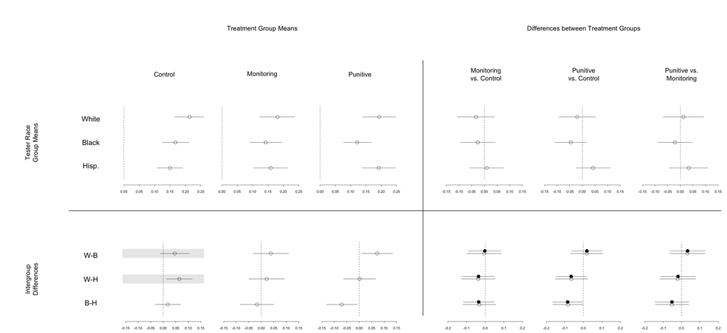

**Figure 1, Panel A: Outcome 1: Net Discrimination in Receiving Callbacks**

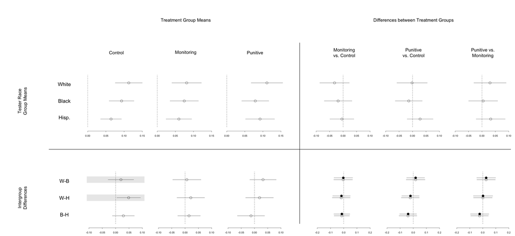

**Figure 1, Panel B: Outcome 2: Net Discrimination in Receiving Offers**

```r
## INDEX

# Make PNG version for Rmd output
png("out_figurea3_6x6_index.png", width=2400, height=1100)
par(oma=c(5,0,0,0), mar=c(5,0,0,0))
layout(matrix(layout_vec, nrow=5, ncol=9, byrow=TRUE), widths=width_spec, heights=height_spec)
# plots
xlims <- list(c(-.3, .3), c(-.35, .35), c(-.35, .35), c(-.35, .35))
itt.plot(y11 = index_11, y12 = index_12, y21 = index_21, y22_np  = index_22,
         y_22_p =meindex.reg, xlims)
# dividers
frame(); abline(h=.5, lwd=2)
frame(); abline(v=.5, lwd=2)
# row labels
frame(); text(.6, .85, "White", cex=rowsub.cex); text(.6, .5, "Black", cex=rowsub.cex); text(.6, .15, "Hisp.", cex=rowsub.cex)
frame(); text(.6, .85, "W-B", cex=rowsub.cex); text(.6, .5, "W-H", cex=rowsub.cex); text(.6, .15, "B-H", cex=rowsub.cex)
# col labels
for(i in 1:6) {
  frame(); text(.5, .5, col_headings[i], cex=colhead.cex)
}
# meta col labels
frame(); text(.5, .5, "Treatment Group Means", cex=colhead.cex)
frame(); text(.5, .5, "Differences between Treatment Groups", cex=colhead.cex)
# meta row labels
frame(); text(.5, .5, "Tester Race\nGroup Means", cex=colhead.cex, srt=90)
frame(); text(.5, .5, "Intergroup\nDifferences", cex=colhead.cex, srt=90)
dev.off()
```

## 3.4 Figure 2: Posterior Densities of Treatment Effects on Discrimination

```r
##=============================================================================##
## Figure 2: Posterior Probabilities
##=============================================================================##

#### ======== FUNCTIONS =========== ####

## function to compute the bayesian analog of the lmfit
## using non-informative priors and Monte Carlo scheme
## based on N samples;
#  see http://www.r-bloggers.com/bayesian-linear-regression-analysis-without-tears-r/

bayes.graph <- function(depvar, treat, weight, block = NULL, main = "Callbacks", #comparison = "Hispanic",
                       trt_text = "Punitive", draws = 10000, xloc = 0.15, yloc = 13, textadj = 1, ylab = "", print_title = FALSE,
                       vertical = TRUE, maxline = FALSE, addlegend = FALSE, addbox = TRUE, ylim = c(0,18)) {

  lmfit <- lm(depvar ~ treat + factor(block), weights = weight)

  bf <- data.frame(arm::sim(lmfit, draws)@coef)
  post_punitive <- bf$treat

  # graph
  dens <- density(post_punitive, bw = 0.01, from = -.17, to = .10) # to = .04 ; bw = 0.005

  left <- quantile(post_punitive, 0)
  x1 <- min(which(dens$x >= left))
  x2 <- max(which(dens$x <  0))

  pct_left <- round((diff(dens$x[1:2])*sum(dens$y[1:x2])) / (diff(dens$x[1:2])*sum(dens$y)), digits = 3) * 100 # % MOC < 0

  main_txt <- ""
  if(print_title) { main_txt <- paste0("Outcome: ", main, "\n(", trt_text, " vs. Control)") }
  plot(dens, xlab = "", ylab = ylab, main = main_txt, bty = "n", lwd = 2, xlim = c(-.15, .15), ylim = ylim, cex.main = 1.5, cex.lab = 1.2, cex.axis = 1, font = 1) #xlim = c(-.17, .10), ylim = c(0,17)
  with(dens, polygon(x=c(x[c(x1,x1:x2,x2)]), y= c(0, y[x1:x2], 0), col="gray"))
  if(maxline) abline(v = mean(post_punitive), col = "red", lty = 2, lwd = 3)
  text(x = xloc, y = yloc, paste0(pct_left, "%"), adj = c(textadj, NA), cex = 1.2)
  text(x = xloc, y = yloc-.8, "less than zero", adj = c(textadj, NA), cex = 1.2)
  if(vertical) abline(v=0)
  if(addbox) box()
}


#### ======== ANALYSES AND GRAPH RESULTS =========== ####

# CREATE PNG OUTPUT FOR RMD

op <- par()
par(op)
png("out_figure2_posteriors.png", width = 1350, height = 750)
par(mfrow = c(2,4), mar=c(2.5,5,5,0.5), family="Helvetica")

# Hispanic
# callback
  bayes.graph(depvar = dat$ncb_wh[dat$TA!=2],
              treat  = (dat$TA1)[dat$TA!=2],
              weight = dat$ipw10[dat$TA!=2],
              block  = dat$block[dat$TA!=2],
              trt_text = "Monitoring",
              ylab = "Discrimination against Hispanics (vs. Whites)",
              print_title = TRUE)

  bayes.graph(depvar = dat$ncb_wh[dat$TA!=1],
              treat  = (dat$TA2)[dat$TA!=1],
              weight = dat$ipw20[dat$TA!=1],
              block  = dat$block[dat$TA!=1],
              print_title = TRUE)

    # offer
  bayes.graph(depvar = dat$noff_wh[dat$TA!=2],
              treat  = (dat$TA==1)[dat$TA!=2],
              weight = dat$ipw[dat$TA!=2],
              block  = dat$block[dat$TA!=2],
              main = "Offers",
              trt_text = "Monitoring",
              print_title = TRUE)

  bayes.graph(depvar = dat$noff_wh[dat$TA!=1],
              treat  = (dat$TA==2)[dat$TA!=1],
              weight = dat$ipw[dat$TA!=1],
              block  = dat$block[dat$TA!=1],
              main = "Offers",
              print_title = TRUE)

  # Black
  # callback
  bayes.graph(depvar = dat$ncb_wb[dat$TA!=2],
              treat  = (dat$TA==1)[dat$TA!=2],
              weight = dat$ipw[dat$TA!=2],
              block  = dat$block[dat$TA!=2],
              trt_text = "Monitoring",
              xloc = -0.15,
              textadj = 0,
              ylab = "Discrimination against Blacks (vs. Whites)")

  bayes.graph(depvar = dat$ncb_wb[dat$TA!=1],
              treat  = (dat$TA==2)[dat$TA!=1],
              weight = dat$ipw[dat$TA!=1],
              block = dat$block[dat$TA!=1],
              xloc = -0.15,
              textadj = 0)

  # offer
  bayes.graph(depvar = dat$noff_wb[dat$TA!=2],
              treat  = (dat$TA==1)[dat$TA!=2],
              weight = dat$ipw[dat$TA!=2],
              block  = dat$block[dat$TA!=2],
              main = "Offers",
              trt_text = "Monitoring",
              xloc = -0.15,
              textadj = 0)

  bayes.graph(depvar = dat$noff_wb[dat$TA!=1],
              treat  = (dat$TA==2)[dat$TA!=1],
              weight = dat$ipw[dat$TA!=1],
              block  = dat$block[dat$TA!=1],
              main = "Offers",
              xloc = -0.15,
              textadj = 0)

dev.off()
```

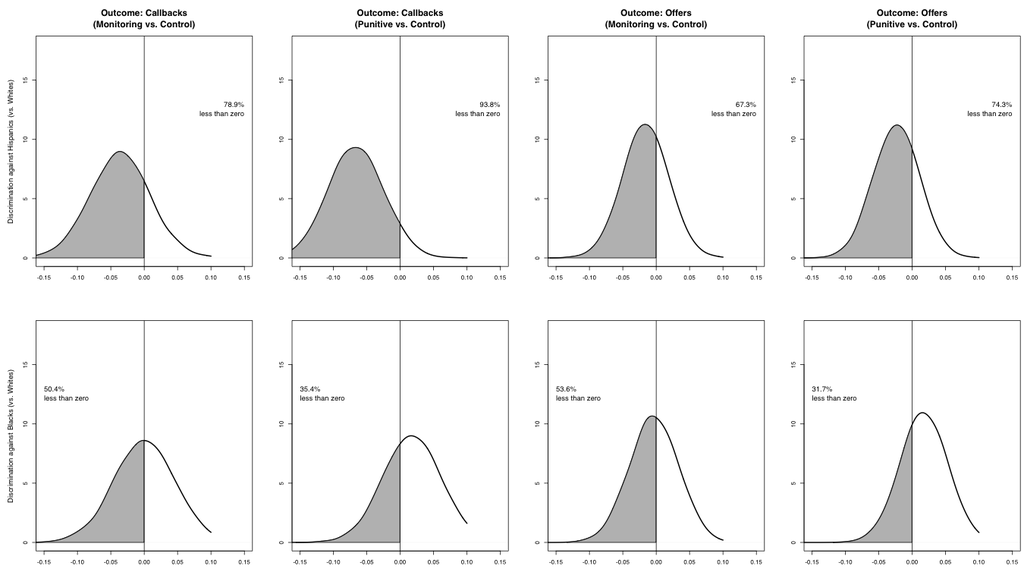

**Figure 2: Posterior Densities of Treatment Effects on Discrimination against Hispanics (top) and African Americans (bottom) Relative to Whites**

```r
##===========================================
# CREATE PDF OUTPUT FOR MANUSCRIPT OUTPUT

pdf("out_figure2_posteriors.pdf", width = 13.5, height = 7.5)
par(mfrow = c(2,4), mar=c(2.5,5,5,0.5), family="Helvetica")
#TA: Treatment assignment -- {Control = 0, Monitoring = 1, Punitive = 2}

# Hispanic
# callback
bayes.graph(dat$ncb_wh[dat$TA!=2], (dat$TA==1)[dat$TA!=2], dat$ipw[dat$TA!=2], dat$block[dat$TA!=2], trt_text = "Monitoring", ylab = "Discrimination against Hispanics (vs. whites)", print_title = TRUE)
bayes.graph(dat$ncb_wh[dat$TA!=1], (dat$TA==2)[dat$TA!=1], dat$ipw[dat$TA!=1], dat$block[dat$TA!=1], print_title = TRUE)


# offer
bayes.graph(dat$noff_wh[dat$TA!=2], (dat$TA==1)[dat$TA!=2], dat$ipw[dat$TA!=2], dat$block[dat$TA!=2], main = "Offers", trt_text = "Monitoring", print_title = TRUE)
bayes.graph(dat$noff_wh[dat$TA!=1], (dat$TA==2)[dat$TA!=1], dat$ipw[dat$TA!=1], dat$block[dat$TA!=1], main = "Offers", print_title = TRUE)

# Black
# callback
bayes.graph(dat$ncb_wb[dat$TA!=2], (dat$TA==1)[dat$TA!=2], dat$ipw[dat$TA!=2], dat$block[dat$TA!=2], trt_text = "Monitoring", xloc = -0.15, textadj = 0, ylab = "Discrimination against Blacks (vs. whites)")
bayes.graph(dat$ncb_wb[dat$TA!=1], (dat$TA==2)[dat$TA!=1], dat$ipw[dat$TA!=1], dat$block[dat$TA!=1], xloc = -0.15, textadj = 0)

# offer
bayes.graph(dat$noff_wb[dat$TA!=2], (dat$TA==1)[dat$TA!=2], dat$ipw[dat$TA!=2], dat$block[dat$TA!=2], main = "Offers", trt_text = "Monitoring", xloc = -0.15, textadj = 0)
bayes.graph(dat$noff_wb[dat$TA!=1], (dat$TA==2)[dat$TA!=1], dat$ipw[dat$TA!=1], dat$block[dat$TA!=1], main = "Offers", xloc = -0.15, textadj = 0)

dev.off()
```

## 3.5 Randomization Check (reported in main text, footnote 14)

```r
set.seed(1234567)
niter = 100

fmla <- " frame + partnered + rent + m.rent + numbr + sqft + m.sqft +
          regime1 + regime2 + regime3 + nnumattr_bh + nnumattr_wh +
          nnumattr_wb + nnumskep_bh + nnumskep_wh + nnumskep_wb + npctskep_bh +
          npctskep_wh + npctskep_wb + nnumpos_bh + nnumpos_wh + nnumpos_wb +
          nnumneu_bh + nnumneu_wh + nnumneu_wb + nnumneg_bh + nnumneg_wh +
          nnumneg_wb + npctpos_bh + npctpos_wh + npctpos_wb + npctneu_bh +
          npctneu_wh + npctneu_wb + npctneg_bh + npctneg_wh + npctneg_wb +
          nanyskep_bh + nanyskep_wh + nanyskep_wb + nanyneg_bh + nanyneg_wh +
          nanyneg_wb + team_gender + broker + callorder.wb + callorder.wh +
          callorder.bh + incrank.wb.gt + incrank.wh.gt + incrank.bh.gt +
          incrank.wb.eq + incrank.wh.eq + incrank.bh.eq + incrank.wb.lt +
          incrank.wh.lt + incrank.bh.lt + boro.brx + boro.brk + boro.mnh +
          boro.que + boro.stn + inc.w.hi + inc.b.hi + inc.h.hi + ll.female +
          m.ll.female + primary_api + primary_blk + primary_hsp + primary_wht +
          primary_age_18to34 + primary_age_35to44 + primary_age_45to64 +
          primary_age_65over + primary_age_unknown + tid.A01 + tid.A10 +
          tid.A11 + tid.A13 + tid.A02 + tid.A21 + tid.A22 + tid.A03 +
          tid.A04 + tid.A05 + tid.A06 + tid.A07 + tid.A08 + tid.A09 +
          tid.B01 + tid.B11 + tid.B12 + tid.B14 + tid.B16 + tid.B02 +
          tid.B20 + tid.B23 + tid.B24 + tid.B25 + tid.B27 + tid.B03 +
          tid.B04 + tid.B06 + tid.B07 + tid.B08 + tid.B09 + tid.C01 +
          tid.C10 + tid.C12 + tid.C13 + tid.C14 + tid.C15 + tid.C02 +
          tid.C27 + tid.C29 + tid.C03 + tid.C31 + tid.C33 + tid.C04 +
          tid.C05 + tid.C06 + tid.C07 + tid.C08 + tid.C09 + as.factor(block)"

# trace=FALSE to suppress output about convergence
mnl_fit <-  multinom(formula = paste("TA ~ ", fmla), data = dat, weight = ipw, trace = FALSE)
kparams = length(mnl_fit$coefnames)
mnl_loglik = -(mnl_fit$AIC - 2*kparams)/2   # log likelihood from actual model

# randomization inference
ri_mat = cbind(1:nrow(dat), dat$block, dat$TA)
blocks = names(table(dat$block))

# recalculate loglik stat for each shuffled vector of assignments
mnl_loglik_ri = rep(NA, niter)
fmla_ri = as.formula(paste0("z_ri ~ ", fmla))
for(j in 1:niter){
  shuffle_mat = list()
  for(i in 1:length(blocks)){
    block_z = ri_mat[ri_mat[,2] == blocks[i],3]
    shuffle_z = sample(block_z, length(block_z), replace=FALSE)
    shuffle_mat[[i]] = cbind(ri_mat[ri_mat[,2] == blocks[i],1:2], shuffle_z)
  }
  shuffle_mat = do.call(rbind, shuffle_mat)
  shuffle_mat = shuffle_mat[order(shuffle_mat[,1]),]
  dat$z_ri = shuffle_mat[,3]
  mnl_fit_ri = multinom(formula=fmla_ri, data=dat, weight=ipw, trace=FALSE)
  kparams = length(mnl_fit_ri$coefnames)
  mnl_loglik_ri[j] = -(mnl_fit_ri$AIC - 2*kparams)/2
}

# calculate p-value
mean(abs(mnl_loglik_ri) >= abs(mnl_loglik))
```

```
[1] 0.97
```

# 4 Appendix Tables and Figures

## 4.1 Table A1 (p. A-2): Distribution of Experimental Subjects by Randomization Block

```r
blockLabs <- rep(c("Brooklyn","Bronx","Manhattan","Queens","Staten Island","Likely Discrimination Frame"), 3)
blockLabs <- blockLabs[-length(blockLabs)]
pcts <- round(prop.table(table(dat$block, dat$TA, useNA="ifany")), 3)
block_dist <- cbind(blockLabs,
                    table(dat$block, dat$TA, useNA="ifany")[,1], pcts[,1],
                    table(dat$block, dat$TA, useNA="ifany")[,2], pcts[,2],
                    table(dat$block, dat$TA, useNA="ifany")[,3], pcts[,3])

block_dist <- rbind(c("Regime 1: 13 Apr 2012 - 9 Sep 2012", rep(NA,6)),
                    block_dist[1:6,],
                    c("Regime 2: 10 Sep 2012 - 7 May 7, 2013", rep(NA,6)),
                    block_dist[7:12,],
                    c("Regime 3: 8 May 2013 to 20 Dec 2013", rep(NA,6)),
                    block_dist[13:17,],
                    c("Total", table(dat$TA)[1], round(table(dat$TA)[1]/sum(table(dat$TA)),3),
                      table(dat$TA)[2], round(table(dat$TA)[2]/sum(table(dat$TA)),3),
                      table(dat$TA)[3], round(table(dat$TA)[3]/sum(table(dat$TA)),3)
                    ))

colnames(block_dist) <- c("Block","Control (N)","Control (Proportion)",
                  "Monitoring (N)","Monitoring (Proportion)",
                  "Punitive (N)","Punitive (Proportion)")

block_distcaption = "Distribution of Experimental Subjects by Randomization Block. Cells contain counts of the number and proportion of experimental subjects randomly assigned to each arm by randomization block. The 17 randomization blocks are defined by the ad's sampling stratum (New York City borough or the likely discrimination, or LD, oversample) and by treatment regime (defined as a distinct design and randomization procedure). There are three treatment regimes. Regime 1 was a 5-arm design (2 of which are not analyzed in this paper) with equal treatment assignment probabilities. Regime 2 was a 3-arm design where the probability of assignment to control was 0.5 and the probability of assignment to the monitoring or punitive conditions was 0.25. Regime 3 was a 3-arm design with equal treatment assignment probabilities. Proportions may not sum to 1 due to rounding."

# show table in Rmd output file
rownames(block_dist) <- NULL
kable(block_dist, caption="**Table A1**")
```

**Table A1**

| Block | Control (N) | Control (Proportion) | Monitoring (N) | Monitoring (Proportion) | Punitive (N) | Punitive (Proportion) |
| --- | --- | --- | --- | --- | --- | --- |
| Regime 1: 13 Apr 2012 - 9 Sep 2012 |  |  |  |  |  |  |
| Brooklyn | 14 | 0.021 | 11 | 0.017 | 17 | 0.026 |
| Bronx | 4 | 0.006 | 3 | 0.005 | 2 | 0.003 |
| Manhattan | 13 | 0.02 | 12 | 0.018 | 18 | 0.028 |
| Queens | 2 | 0.003 | 3 | 0.005 | 6 | 0.009 |
| Staten Island | 1 | 0.002 | 1 | 0.002 | 0 | 0 |
| Likely Discrimination Frame | 8 | 0.012 | 8 | 0.012 | 9 | 0.014 |
| Regime 2: 10 Sep 2012 - 7 May 7, 2013 |  |  |  |  |  |  |
| Brooklyn | 63 | 0.096 | 24 | 0.037 | 29 | 0.044 |
| Bronx | 21 | 0.032 | 10 | 0.015 | 11 | 0.017 |
| Manhattan | 50 | 0.077 | 32 | 0.049 | 23 | 0.035 |
| Queens | 28 | 0.043 | 10 | 0.015 | 14 | 0.021 |
| Staten Island | 8 | 0.012 | 2 | 0.003 | 3 | 0.005 |
| Likely Discrimination Frame | 11 | 0.017 | 4 | 0.006 | 4 | 0.006 |
| Regime 3: 8 May 2013 to 20 Dec 2013 |  |  |  |  |  |  |
| Brooklyn | 13 | 0.02 | 23 | 0.035 | 14 | 0.021 |
| Bronx | 6 | 0.009 | 3 | 0.005 | 8 | 0.012 |
| Manhattan | 25 | 0.038 | 18 | 0.028 | 25 | 0.038 |
| Queens | 8 | 0.012 | 7 | 0.011 | 14 | 0.021 |
| Staten Island | 4 | 0.006 | 3 | 0.005 | 3 | 0.005 |
| Total | 279 | 0.427 | 174 | 0.266 | 200 | 0.306 |

## 4.2 Table A2 (p. A-3): Incidence of Early Stage Discrimination

```r
# A: BLACK , B: HISPANIC , C: WHITE

es <- c("contact", "sched",   "numattr", "numskep", "numpos", "numneu",
        "numneg",  "pctskep", "pctpos",  "pctneu",  "pctneg",  "anyskep", "anyneg")

summm <- function(x, group1 = "C", group2 = "A") {
  es1 <- paste0(x, "_", group1); es2 <- paste0(x, "_", group2)

  # audit sample
  aud_maj_mean <- mean(aud[[es1]])
  aud_min_mean <- mean(aud[[es2]])
  aud_diff     <- as.numeric(aud_maj_mean) - as.numeric(aud_min_mean)
  aud_P        <- t.test(x=aud[[es1]], y=aud[[es2]], alternative="two.sided",
                         paired=TRUE, conf.level=0.95)$p.value
  aud_N        <- length(aud[[es1]])

  # experimental sample
  exp_maj_mean <- mean(aud[[es1]][aud$insamp=="1" & !is.na(aud$insamp) ])
  exp_min_mean <- mean(aud[[es2]][aud$insamp=="1" & !is.na(aud$insamp) ])
  exp_diff <-  exp_maj_mean - exp_min_mean
  exp_P <-  t.test(x=aud[[es1 ]][aud$insamp=="1" & !is.na(aud$insamp) ],
                   y=aud[[es2 ]][aud$insamp=="1" & !is.na(aud$insamp) ], alternative="two.sided", paired=TRUE, conf.level=0.95)$p.value
  exp_N <- length(aud[[es1]][aud$insamp=="1" & !is.na(aud$insamp) ])

  # control group
  ctrl_maj_mean <- mean(aud[[es1]][aud$insamp=="1"  & !is.na(aud$insamp) & aud$TA==0])
  ctrl_min_mean <- mean(aud[[es2]][aud$insamp=="1"  & !is.na(aud$insamp) & aud$TA==0])
  ctrl_diff <- ctrl_maj_mean -  ctrl_min_mean
  ctrl_P <- t.test(x=aud[[es1 ]][aud$insamp=="1" & !is.na(aud$insamp) & aud$TA==0],
                   y=aud[[es2 ]][aud$insamp=="1"  & !is.na(aud$insamp) & aud$TA==0], alternative="two.sided", paired=TRUE, conf.level=0.95)$p.value
  ctrl_N <- length(aud[[es1]][aud$insamp=="1" & !is.na(aud$insamp)  & aud$TA==0])

  # return
  c(aud_maj_mean = aud_maj_mean, aud_min_mean = aud_min_mean,
    aud_diff = aud_diff, aud_P = aud_P, aud_N = aud_N,
    exp_maj_mean = exp_maj_mean, exp_min_mean = exp_min_mean,
    exp_diff = exp_diff, exp_P = exp_P, exp_N = exp_N,
    ctrl_maj_mean = ctrl_maj_mean, ctrl_min_mean = ctrl_min_mean,
    ctrl_diff = ctrl_diff, ctrl_P = ctrl_P, ctrl_N = ctrl_N)
}

wb <- cbind(es.wb.labs, t(sapply(es, summm, group1 = "C", group2 = "A")))
wh <- cbind(es.wh.labs, t(sapply(es, summm, group1 = "C", group2 = "B")))
bh <- cbind(es.bh.labs, t(sapply(es, summm, group1 = "A", group2 = "B")))
```

```r
es_discrim_full_table <- rbind(wb, wh, bh)
table_a2 <- es_discrim_full_table[c(1,2,14,15,27,28),1:6]
kable(table_a2, caption="**Table A2**",
      col.names = c("Measure", "Majority Group Mean", "Minority Group Mean",
                    "Difference (Maj-Min)", "p-value", "[N]"),
      row.names = FALSE)
```

**Table A2**

| Measure | Majority Group Mean | Minority Group Mean | Difference (Maj-Min) | p-value | [N] |
| --- | --- | --- | --- | --- | --- |
| Any contact (White vs. Black) | 0.512 | 0.524 | -0.012 | (0.184) | [2711] |
| Scheduling appointment (White vs. Black) | 0.348 | 0.361 | -0.013 | (0.035) | [2711] |
| Any contact (White vs. Hispanic) | 0.512 | 0.512 | 0 | (0.968) | [2711] |
| Scheduling appointment (White vs. Hispanic) | 0.348 | 0.354 | -0.006 | (0.283) | [2711] |
| Any contact (Black vs. Hispanic) | 0.524 | 0.512 | 0.012 | (0.189) | [2711] |
| Scheduling appointment (Black vs. Hispanic) | 0.361 | 0.354 | 0.007 | (0.284) | [2711] |

```r
#### F-test for the null hypothesis that race does not matter for making any contact or for scheduling appointment

# A: BLACK , B: HISPANIC , C: WHITE

aud.rs <- melt(aud[,c("cid", "contact_A", "contact_B", "contact_C", "sched_A", "sched_B", "sched_C")], id.vars="cid")

aud.rs$ttype <- sapply(strsplit(as.character(aud.rs$variable), "_", fixed=TRUE), function(x) x[2])
aud.rs$variable <- sapply(strsplit(as.character(aud.rs$variable), "_", fixed=TRUE), function(x) x[1])
aud.rs <- dcast(aud.rs, cid + ttype ~ variable, value.var="value")

fit.contact <- lm(contact ~ ttype, data = aud.rs)
fit.sched   <- lm(sched   ~ ttype, data = aud.rs)

print("F-test of the null that tester race predicts whether the tester makes any contact with the landlord")
```

```
[1] "F-test of the null that tester race predicts whether the tester makes any contact with the landlord"
```

```r
print(summary(fit.contact))
```

```
Call:
lm(formula = contact ~ ttype, data = aud.rs)

Residuals:
    Min      1Q  Median      3Q     Max
-0.5242 -0.5124  0.4758  0.4876  0.4880

Coefficients:
             Estimate Std. Error t value Pr(>|t|)
(Intercept)  0.524161   0.009599  54.605   <2e-16 ***
ttypeB      -0.012173   0.013575  -0.897    0.370
ttypeC      -0.011804   0.013575  -0.870    0.385
---
Signif. codes:  0 '***' 0.001 '**' 0.01 '*' 0.05 '.' 0.1 ' ' 1

Residual standard error: 0.4998 on 8130 degrees of freedom
Multiple R-squared:  0.000128,  Adjusted R-squared:  -0.000118
F-statistic: 0.5203 on 2 and 8130 DF,  p-value: 0.5944
```

```r
print("F-test of the null that tester race predicts whether the tester successfully schedules an appointment")
```

```
[1] "F-test of the null that tester race predicts whether the tester successfully schedules an appointment"
```

```r
print(summary(fit.sched))
```

```
Call:
lm(formula = sched ~ ttype, data = aud.rs)

Residuals:
    Min      1Q  Median      3Q     Max
-0.3611 -0.3545 -0.3482  0.6389  0.6518

Coefficients:
             Estimate Std. Error t value Pr(>|t|)
(Intercept)  0.361121   0.009189  39.299   <2e-16 ***
ttypeB      -0.006640   0.012995  -0.511    0.609
ttypeC      -0.012910   0.012995  -0.993    0.321
---
Signif. codes:  0 '***' 0.001 '**' 0.01 '*' 0.05 '.' 0.1 ' ' 1

Residual standard error: 0.4785 on 8130 degrees of freedom
Multiple R-squared:  0.0001214, Adjusted R-squared:  -0.0001246
F-statistic: 0.4936 on 2 and 8130 DF,  p-value: 0.6104
```

## 4.3 Figure A2 (p. A-5): Cumulative Number of Cases Over Implementation Period

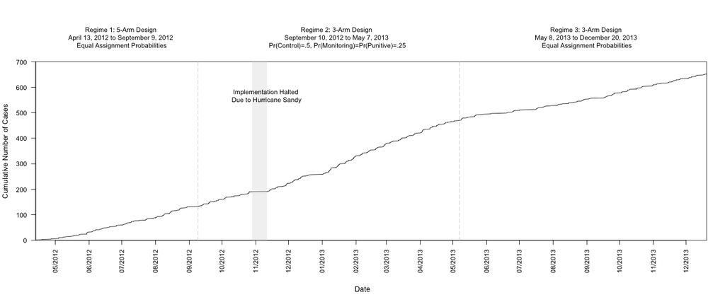

**Figure A2**

```r
dat$casedate <- as.Date(dat$casedate, format="%Y-%m-%d")
casedate <- dat$casedate[order(dat$casedate)]

# generate .png
png("out_figurea2_cases_over_time.png", height=500, width=1200)
par(oma=c(2,0,3,0), xpd=TRUE)

plot(casedate, 1:length(casedate), xaxt="n", yaxt="n", type="l", ylim=c(0,700), xlab="", ylab="Cumulative Number of Cases", xaxs="i", yaxs="i")
axis.Date(side=1, at=seq(as.Date("2012-04-01"), as.Date("2014-01-01"), "month"), format="%m/%Y", las=2, cex.axis=0.9)
axis(side=2, at=seq(0,700,100), labels=seq(0,700,100), cex.axis=0.9, las=1)
polygon(x=c(rep(as.Date("2012-10-29"),2), rep(as.Date("2012-11-11"),2)),
        y=c(700,0,0,700),
        col=rgb(.8,.8,.8,.25),
        border=rgb(.8,.8,.8,.25))
text(x=as.Date("2012-11-11"), y=600, "Implementation Halted \nDue to Hurricane Sandy", cex=.9, pos=1)
mtext(side=1, "Date", outer=TRUE)

segments(x0=as.Date("2012-09-09"), y0=700, x1=as.Date("2012-09-09"), y1=0, lty=5, col="grey80")
segments(x0=as.Date("2013-05-07"), y0=700, x1=as.Date("2013-05-07"), y1=0, lty=5, col="grey80")

text(x=as.Date("2012-07-01"), y=840, "Regime 1: 5-Arm Design \nApril 13, 2012 to September 9, 2012 \nEqual Assignment Probabilities", cex=.9, pos=1)
text(x=as.Date("2013-01-15"), y=840, "Regime 2: 3-Arm Design \nSeptember 10, 2012 to May 7, 2013 \nPr(Control)=.5, Pr(Monitoring)=Pr(Punitive)=.25", cex=.9, pos=1)
text(x=as.Date("2013-09-01"), y=840, "Regime 3: 3-Arm Design \nMay 8, 2013 to December 20, 2013 \nEqual Assignment Probabilities", cex=.9, pos=1)

invisible(dev.off())
```

## 4.4 Figure A3 (p. A-6): Discrimination Levels and Treatment Effects using the Subjective Discrimination Index

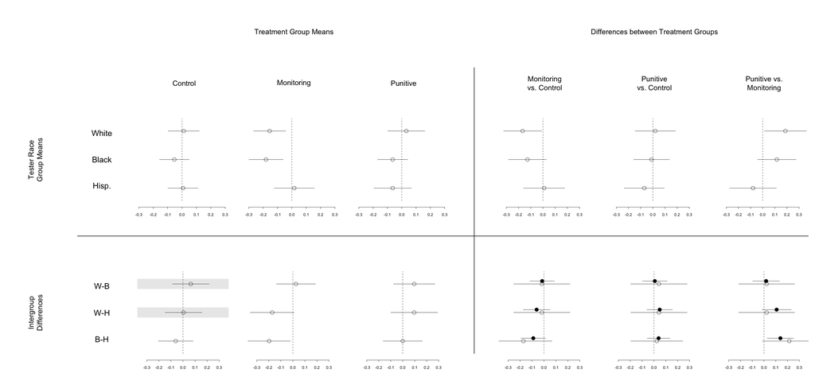

**Figure A3: Net Discrimination in Subjective Discrimination Index**

## 4.5 Figure A4 (p. A-17): Estimates of Tester Random Effects on Outcome Measures

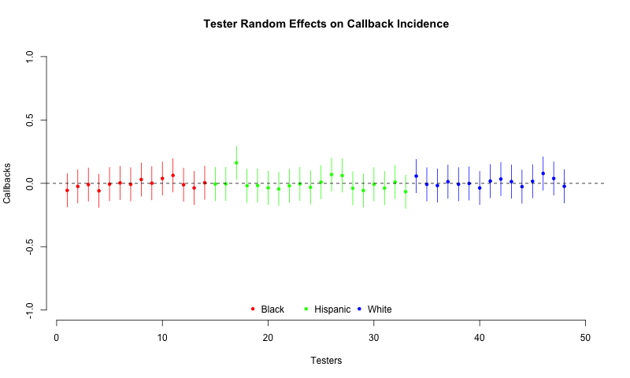

**Figure A4, panel a: Post-Visit Callback**

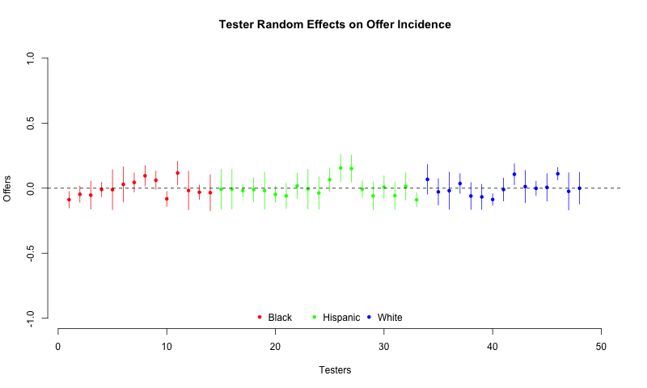

**Figure A4, panel b: Post-Visit Offer**

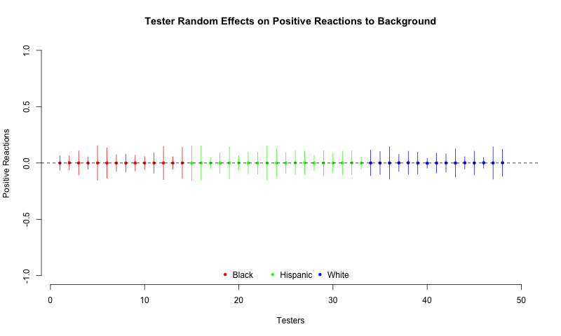

**Figure A4, panel c: Positive Biographical Feedback**

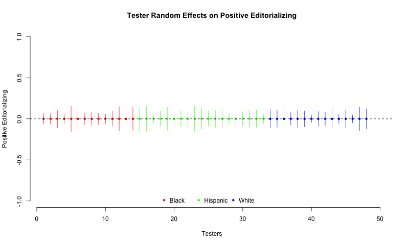

**Figure A4, panel d: Positive Editorializing**

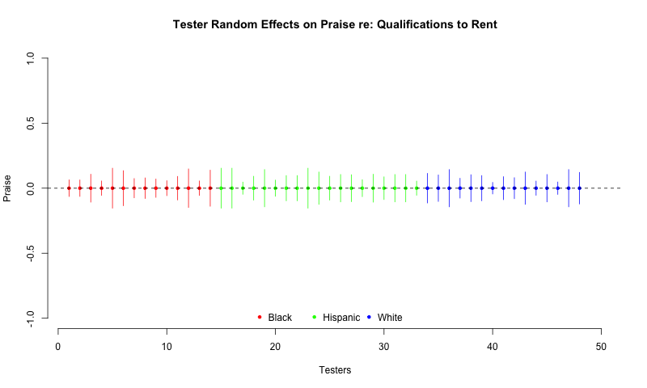

**Figure A4, panel e: Praised Rental Qualifications**

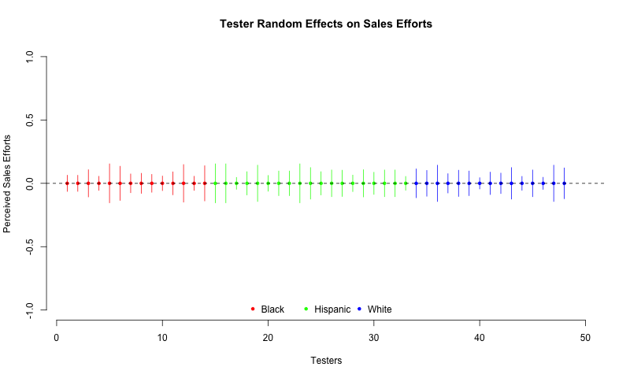

**Figure A4, panel f: Sales Efforts**

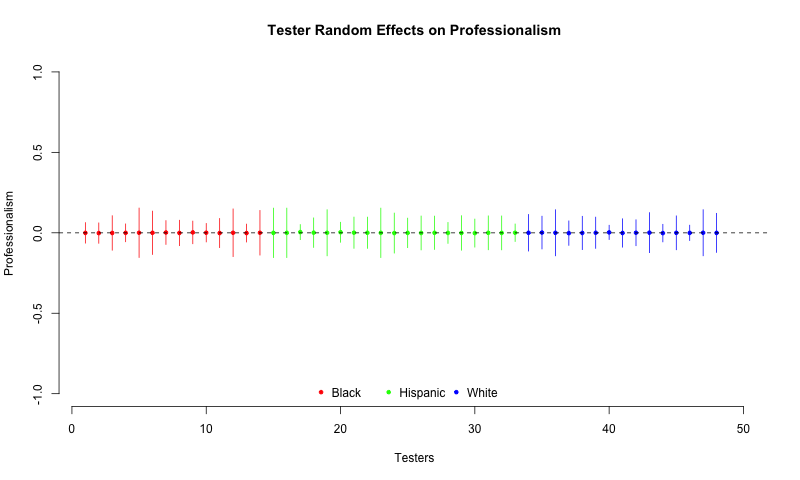

**Figure A4, panel g: Professionalism**

```r
ctx$weekday <- as.factor(weekdays(as.Date(ctx$sfa_B4_apptdate, format="%m/%d/%y")))

anova_fig <- data.frame(outcome = c("cb","off","qualpraise","sales","posedit","posbg","prof"),
                        ylab = c("Callbacks", "Offers", "Praise", "Perceived Sales Efforts",
                                 "Positive Editorializing", "Positive Reactions", "Professionalism"),
                        title = c("Tester Random Effects on Callback Incidence",
                                  "Tester Random Effects on Offer Incidence",
                                  "Tester Random Effects on Praise re: Qualifications to Rent",
                                  "Tester Random Effects on Sales Efforts",
                                  "Tester Random Effects on Positive Editorializing",
                                  "Tester Random Effects on Positive Reactions to Background",
                                  "Tester Random Effects on Professionalism"))

# MAKE GRAPHS

for(ii in 1:nrow(anova_fig)){
  model     <- lmer(paste0(anova_fig$outcome[ii],
                       " ~ (1|tid) + (1|ttype) + callorder + weekday + partnered
                                   + numbr + anyskep + anyneg + (1|team_gender)"), data=ctx)
  model_off <- lmer(paste0(anova_fig$outcome[2],
                           " ~ (1|tid) + (1|ttype) + callorder + weekday + partnered
                                        + numbr + anyskep + anyneg + (1|team_gender)"), data=ctx)

  ifelse(ii>=2, se <- se.ranef(model_off)[[1]][i,1], se <- se.ranef(model)[[1]][i,1])

  i <- 1:(length(ranef(model)[[1]][,1]))
  y <- ranef(model)[[1]][,1] # individual tester RE
  types <- c(rep(0,14), rep(1,19), rep(2,15))
  col   <- rainbow(3)[types+1]

  # output PNG file for Rmd output
  png(paste0("out_figurea4",letters[ii],"_anova_",anova_fig$outcome[ii],".png"), width=800)
  par(0,0,0,0)
  plot(i, y, col = col, ylim=c(-1.0,1),xlim=c(1,50),xlab="Testers", ylab=anova_fig$ylab[ii],main=anova_fig$title[ii],pch=20,bty="n")
  legend("bottom", c("Black","Hispanic","White"), pch=20, col=rainbow(3),horiz=T,bty="n")
  segments(i, y + 2*se, i, y - 2*se,  col = col)
  abline(a=0,b=0,lty=2)
  invisible(dev.off())
}
```

```r
### The following analysis corresponds to the analyses described in footnote 22 in the article.
ctx$weekday <- as.factor(weekdays(as.Date(ctx$sfa_B4_apptdate, format="%m/%d/%y")))
dat_tid <- dat[,c("cid","TA",names(dat)[grepl("tid",names(dat))])]
dat_tid <- cbind(dat_tid[,c("cid","TA")], t(apply(dat_tid[,3:ncol(dat_tid)], 1, function(J) names(dat_tid[,3:ncol(dat_tid)])[which(J==1)])))

dat_tid_1 <- as.data.frame(dat_tid[,c(1,2,3)], stringsAsFactors=FALSE)
dat_tid_2 <- as.data.frame(dat_tid[,c(1,2,4)], stringsAsFactors=FALSE)
dat_tid_3 <- as.data.frame(dat_tid[,c(1,2,5)], stringsAsFactors=FALSE)

dat_tid_1[,3] <- as.character(dat_tid_1[,3])
dat_tid_2[,3] <- as.character(dat_tid_2[,3])
dat_tid_3[,3] <- as.character(dat_tid_3[,3])
names(dat_tid_1)[3] <- names(dat_tid_2)[3] <- names(dat_tid_3)[3] <- "tid"
dat_tid <- rbind(dat_tid_1, dat_tid_2, dat_tid_3)
dat_tid$tid <- gsub("tid.","",dat_tid$tid,fixed=TRUE)
dat_tid$ttype <- substr(dat_tid$tid, 1, 1)

dat_sub <- dat[,c("cid","TA","team_gender","callorder","partnered","numbr",
       paste0(rep(c("anyskep","anyneg","cb","off","prof","posedit","posbg","qualpraise","sales"), 3),
              rep(c("_A","_B","_C"), each=9))
       )]

dmelt <- melt(dat_sub, id.vars=c("cid", "TA", "team_gender", "callorder", "partnered", "numbr"))
dmelt$ttype <- ifelse(grepl("_A", dmelt$variable, fixed=TRUE), "A",
                      ifelse(grepl("_B", dmelt$variable, fixed=TRUE), "B", "C"))
dmelt$variable <- gsub("_A", "", dmelt$variable, fixed=TRUE)
dmelt$variable <- gsub("_B", "", dmelt$variable, fixed=TRUE)
dmelt$variable <- gsub("_C", "", dmelt$variable, fixed=TRUE)
dat_sub2 <- dcast(dmelt, cid + TA + team_gender + callorder + partnered + numbr + ttype ~ variable, value.var="value")
dat2 <- join(dat_tid, dat_sub2, by=c("cid","TA","ttype"), type="left", match="all")

ctx_sub <- ctx[,c("cid","weekday")]
ctx_sub <- ctx_sub[!duplicated(ctx_sub$cid),]
#ctx[ctx$cid %in% ctx_sub$cid[is.na(ctx_sub$weekday)] & !is.na(ctx$weekday),c("cid","weekday")]
ctx_sub$weekday <- ifelse(ctx_sub$cid == 11108, "Wednesday", ctx_sub$weekday)
ctx_sub$weekday <- ifelse(ctx_sub$cid == 12116,    "Friday", ctx_sub$weekday)
ctx_sub$weekday <- ifelse(ctx_sub$cid == 12608,    "Monday", ctx_sub$weekday)
ctx_sub$weekday <- ifelse(ctx_sub$cid == 13361,    "Monday", ctx_sub$weekday)
ctx_sub$weekday <- ifelse(ctx_sub$cid == 15734,    "Friday", ctx_sub$weekday)
ctx_sub$weekday <- ifelse(ctx_sub$cid == 19446,  "Thursday", ctx_sub$weekday)
ctx_sub$weekday <- ifelse(ctx_sub$cid == 26324,    "Friday", ctx_sub$weekday)
ctx_sub$weekday <- ifelse(ctx_sub$cid == 30165,    "Friday", ctx_sub$weekday)
ctx_sub$weekday <- ifelse(is.na(ctx_sub$weekday), "None", ctx_sub$weekday)

dat3 <- join(dat2, ctx_sub, by="cid", type="left", match="all")

model.callback.0 <- lmer(cb ~ (1|tid) + (1|ttype) + callorder + weekday +
                         partnered + numbr + anyskep + anyneg + (1|team_gender),
                       data=dat3, subset=(TA==0))

model.offer.0 <- lmer(off ~ (1|tid) + (1|ttype) + callorder + weekday +
                      partnered + numbr + anyskep + anyneg + (1|team_gender),
                    data=dat3, subset=(TA==0))

model.callback.all <- lmer(cb ~ (1|tid) + (1|ttype) + callorder + weekday +
                           partnered + numbr + anyskep + anyneg + (1|team_gender),
                         data=dat3)

model.offer.all <- lmer(off ~ (1|tid) + (1|ttype) + callorder + weekday +
                        partnered + numbr + anyskep + anyneg + (1|team_gender),
                      data=dat3)

re_out <- list(model.callback.0   ,
               model.offer.0      ,
               model.callback.all ,
               model.offer.all    )

re_table <- lapply(re_out, function(J){
  x <- as.data.frame(VarCorr(J))
  x[,4] <- round(x[,4], 4)
  x <- x[,c(1,4)]
  return(x)
})

re_table <- do.call(cbind, re_table)
re_table <- re_table[,-c(3,5,7)]
re_table[,1] <- c("Estimated Variance of Varying Tester Intercepts",
                  "Estimated Variance of Varying Tester Race Intercepts",
                  "Estimated Variance of Varying Tester Team Gender Intercepts",
                  "Estimated Residual Variance")
colnames(re_table) <- c("", "Control Group, Outcome: Callback", "Control Group, Outcome: Offer",
                        "Experimental Sample, Outcome: Callback", "Experimental Sample, Outcome: Offer")

kable(re_table)
```

|  | Control Group, Outcome: Callback | Control Group, Outcome: Offer | Experimental Sample, Outcome: Callback | Experimental Sample, Outcome: Offer |
| --- | --- | --- | --- | --- |
| Estimated Variance of Varying Tester Intercepts | 0.0034 | 0.0046 | 0.0035 | 0.0048 |
| Estimated Variance of Varying Tester Race Intercepts | 0.0002 | 0.0000 | 0.0003 | 0.0000 |
| Estimated Variance of Varying Tester Team Gender Intercepts | 0.0010 | 0.0000 | 0.0010 | 0.0000 |
| Estimated Residual Variance | 0.1408 | 0.0759 | 0.1352 | 0.0740 |

## 4.6 Table A4 (p. A-20): Selected Characteristics of Housing Units in the Audit and Experimental Samples

We summarize selected *pre-treatment* characteristics of housing units in the audit and experimental samples. To ensure the measures are *pre-treatment* quantities, we summarize characteristics of housing units that are posted on and scraped from the original Craigslist ads.

```r
# Helper functions and code to calculate descriptive statistics
stratum_labels <- c("Total", "Brooklyn", "Bronx", "Manhattan", "Queens", "Staten Island", "Likely Discrimination Frame")


# descriptive_f: A function to compute descriptive statistics e.g. mean, sd, min, max..
calc_descriptives <- function(descriptive_f, df, x, label, digs = 2) {
  x <- c(descriptive_f(df[[x]], na.rm=TRUE),
              descriptive_f(df[[x]][ df[["frame"]] == "representative" & df[["boro"]] == "brk" ], na.rm=TRUE),
              descriptive_f(df[[x]][ df[["frame"]] == "representative" & df[["boro"]] == "brx" ], na.rm=TRUE),
              descriptive_f(df[[x]][ df[["frame"]] == "representative" & df[["boro"]] == "mnh" ], na.rm=TRUE),
              descriptive_f(df[[x]][ df[["frame"]] == "representative" & df[["boro"]] == "que" ], na.rm=TRUE),
              descriptive_f(df[[x]][ df[["frame"]] == "representative" & df[["boro"]] == "stn" ], na.rm=TRUE),
              descriptive_f(df[[x]][ df[["frame"]] != "representative" ], na.rm=TRUE))

  out <- round(x, digs)

 if(identical(descriptive_f, sd))  out <- paste0("(", out, ")")
  out
}


calc_pct_ses <- function(df, x, label, digs=NULL) {

  x_prop <- c(mean(df[[x]], na.rm=TRUE),
              mean(df[[x]][ df[["frame"]] == "representative" & df[["boro"]] == "brk" ], na.rm=TRUE),
              mean(df[[x]][ df[["frame"]] == "representative" & df[["boro"]] == "brx" ], na.rm=TRUE),
              mean(df[[x]][ df[["frame"]] == "representative" & df[["boro"]] == "mnh" ], na.rm=TRUE),
              mean(df[[x]][ df[["frame"]] == "representative" & df[["boro"]] == "que" ], na.rm=TRUE),
              mean(df[[x]][ df[["frame"]] == "representative" & df[["boro"]] == "stn" ], na.rm=TRUE),
              mean(df[[x]][ df[["frame"]] != "representative" ], na.rm=TRUE))

  x_sd <- c(sd(df[[x]], na.rm=TRUE),
            sd(df[[x]][ df[["frame"]] == "representative" & df[["boro"]] == "brk" ], na.rm=TRUE),
            sd(df[[x]][ df[["frame"]] == "representative" & df[["boro"]] == "brx" ], na.rm=TRUE),
            sd(df[[x]][ df[["frame"]] == "representative" & df[["boro"]] == "mnh" ], na.rm=TRUE),
            sd(df[[x]][ df[["frame"]] == "representative" & df[["boro"]] == "que" ], na.rm=TRUE),
            sd(df[[x]][ df[["frame"]] == "representative" & df[["boro"]] == "stn" ], na.rm=TRUE),
            sd(df[[x]][ df[["frame"]] != "representative" ], na.rm=TRUE))

  x_n <- c(sum(!is.na(df[[x]])),
           sum(!is.na(df[[x]][ df[["frame"]] == "representative" & df[["boro"]] == "brk" ])),
           sum(!is.na(df[[x]][ df[["frame"]] == "representative" & df[["boro"]] == "brx" ])),
           sum(!is.na(df[[x]][ df[["frame"]] == "representative" & df[["boro"]] == "mnh" ])),
           sum(!is.na(df[[x]][ df[["frame"]] == "representative" & df[["boro"]] == "que" ])),
           sum(!is.na(df[[x]][ df[["frame"]] == "representative" & df[["boro"]] == "stn" ])),
           sum(!is.na(df[[x]][ df[["frame"]] != "representative" ]))
           )

  x_se <- x_sd / sqrt(x_n)

  if(is.null(digs)) digs <- 2
  x_pct <- sprintf( paste0("%.",digs,"f") , round(x_prop * 100, digs) )
  x_se <- paste0("(", sprintf( paste0("%.",digs,"f") , round(x_se * 100, digs) ) ,")")

  x <- cbind(x_pct, x_se)
  colnames(x) <- paste0(label, c("_p", "_se"))
  rownames(x) <- NULL
  return(x)
}

#----------------------------------------#
# Panel A: Number of units

panel_a_aud_n <- c(nrow(aud),
                   table(aud$boro[aud$frame == "representative"]),
                   nrow(aud[aud$frame != "representative",]))

panel_a_aud_p <- paste0("(", sprintf("%.2f", round(panel_a_aud_n / nrow(aud) * 100, 2))  ,")")

panel_a_exp_n <- c(nrow(dat),
                   table(dat$boro[dat$frame == "representative"]),
                   nrow(dat[dat$frame != "representative",]))
panel_a_exp_p <- paste0("(", sprintf("%.2f", round(panel_a_exp_n / nrow(dat) * 100, 2))  ,")")

panel_a_trt_n <- c(nrow(dat[dat$TA != 0,]),
                   table(dat$boro[dat$frame == "representative" & dat$TA != 0]),
                   nrow(dat[dat$frame != "representative" & dat$TA != 0,]))
panel_a_trt_p <- paste0("(", sprintf("%.2f", round(panel_a_trt_n / nrow(dat[dat$TA != 0,]) * 100, 2)) ,")")

panel_a_con_n <- c(nrow(dat[dat$TA == 0,]),
                   table(dat$boro[dat$frame == "representative" & dat$TA == 0]),
                   nrow(dat[dat$frame != "representative" & dat$TA == 0,]))
panel_a_con_p <- paste0("(", sprintf("%.2f", round(panel_a_con_n / nrow(dat[dat$TA == 0,]) * 100, 2)) ,")")

tab_a4_panel_a <- cbind(stratum_labels,
                        panel_a_aud_n,
                        panel_a_aud_p,
                        panel_a_exp_n,
                        panel_a_exp_p,
                        panel_a_trt_n,
                        panel_a_trt_p,
                        panel_a_con_n,
                        panel_a_con_p)

rownames(tab_a4_panel_a) <- NULL
colnames(tab_a4_panel_a) <- gsub("panel_a_", "", colnames(tab_a4_panel_a), fixed=TRUE)

kable(tab_a4_panel_a, col.names=c("Stratum", "Audit Sample (N)", "Audit Sample (%)",
                                  "Exp Sample (N)", "Exp Sample (%)",
                                  "Any Treatment (N)", "Any Treatment (%)",
                                  "Control (N)", "Control (%)"),
      caption="**Table A4, Panel A. Number of Units (Scraped from Craigslist).**")
```

**Table A4, Panel A. Number of Units (Scraped from Craigslist).**

| Stratum | Audit Sample (N) | Audit Sample (%) | Exp Sample (N) | Exp Sample (%) | Any Treatment (N) | Any Treatment (%) | Control (N) | Control (%) |
| --- | --- | --- | --- | --- | --- | --- | --- | --- |
| Total | 2711 | (100.00) | 653 | (100.00) | 374 | (100.00) | 279 | (100.00) |
| Brooklyn | 801 | (29.55) | 208 | (31.85) | 118 | (31.55) | 90 | (32.26) |
| Bronx | 337 | (12.43) | 68 | (10.41) | 37 | (9.89) | 31 | (11.11) |
| Manhattan | 668 | (24.64) | 216 | (33.08) | 128 | (34.22) | 88 | (31.54) |
| Queens | 495 | (18.26) | 92 | (14.09) | 54 | (14.44) | 38 | (13.62) |
| Staten Island | 254 | (9.37) | 25 | (3.83) | 12 | (3.21) | 13 | (4.66) |
| Likely Discrimination Frame | 156 | (5.75) | 44 | (6.74) | 25 | (6.68) | 19 | (6.81) |

```r
#----------------------------------------#
# Panel B: Monthly asking price (mean)
tab_a4_panel_b <- cbind(stratum_labels,
                    calc_descriptives(mean, df = aud,               x = "rent", label = "aud"),
                    calc_descriptives(sd,   df = aud,               x = "rent", label = "aud"),
                    calc_descriptives(mean, df = dat,               x = "rent", label = "exp"),
                    calc_descriptives(sd,   df = dat,               x = "rent", label = "exp"),
                    calc_descriptives(mean, df = dat[dat$TA != 0,], x = "rent", label = "trt"),
                    calc_descriptives(sd,   df = dat[dat$TA != 0,], x = "rent", label = "trt"),
                    calc_descriptives(mean, df = dat[dat$TA == 0,], x = "rent", label = "con"),
                    calc_descriptives(sd,   df = dat[dat$TA == 0,], x = "rent", label = "con"))



kable(tab_a4_panel_b, col.names=c("Stratum", "Audit Sample (Mean)", "Audit Sample (SD)",
                                  "Exp Sample (Mean)", "Exp Sample (SD)",
                                  "Any Treatment (Mean)", "Any Treatment (SD)",
                                  "Control (Mean)", "Control (SD)"),
      caption="**Table A4, Panel B. Monthly Asking Rental Price ($, Scraped from Craigslist).**")
```

**Table A4, Panel B. Monthly Asking Rental Price ($, Scraped from Craigslist).**

| Stratum | Audit Sample (Mean) | Audit Sample (SD) | Exp Sample (Mean) | Exp Sample (SD) | Any Treatment (Mean) | Any Treatment (SD) | Control (Mean) | Control (SD) |
| --- | --- | --- | --- | --- | --- | --- | --- | --- |
| Total | 2340 | (4721.74) | 2429.74 | (1208.02) | 2411.23 | (1163.67) | 2456.26 | (1271.73) |
| Brooklyn | 2190.57 | (1049.32) | 2319.49 | (956.68) | 2285.06 | (854.67) | 2370.2 | (1096.14) |
| Bronx | 2345.55 | (13616.75) | 1545.64 | (688.14) | 1506.96 | (675.92) | 1596.53 | (719.2) |
| Manhattan | 3251.67 | (1600.49) | 3162.99 | (1447.25) | 3133.9 | (1404.18) | 3206.12 | (1520.28) |
| Queens | 1718.19 | (562.32) | 1885.07 | (557.62) | 1846.75 | (449.9) | 1940.82 | (693.15) |
| Staten Island | 1383.49 | (511.19) | 1335.62 | (596.31) | 1368.89 | (655.17) | 1292.86 | (559.34) |
| Likely Discrimination Frame | 2479.07 | (1451.93) | 2321.16 | (736.25) | 2336.08 | (778.38) | 2301.53 | (697.4) |